# 1. N维数组

① 机器学习用的最多的是N维数组，N维数组是机器学习和神经网络的主要数据结构。

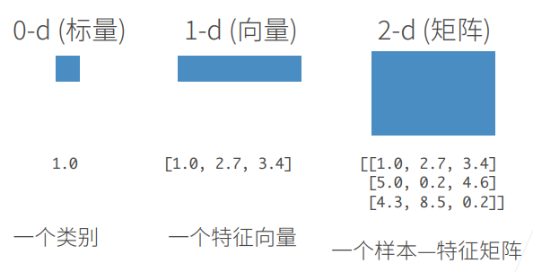

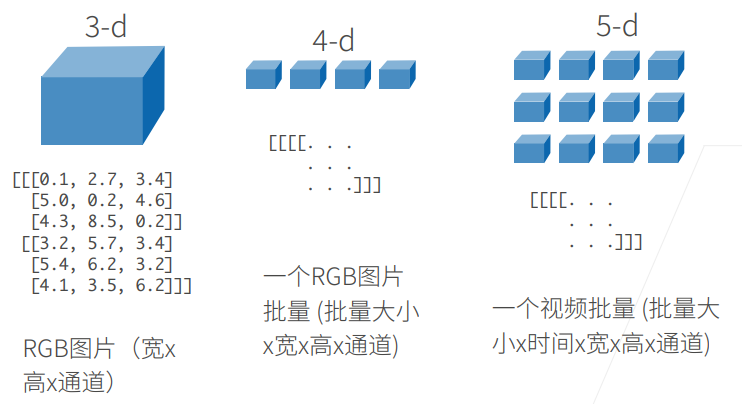

# 2. 创建数组

① 创建数组需要：形状、数据类型、元素值。

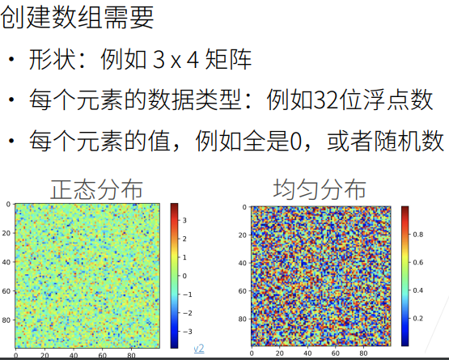

# 3. 访问元素

① 可以根据切片，或者间隔步长访问元素。

② [::3,::2]是每隔3行、2列访问。

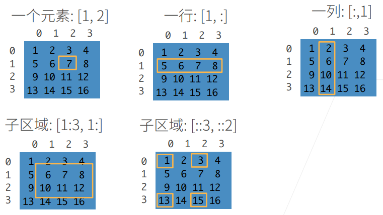

# 4. 张量数据操作

## 4.1 导入torch库

① 虽然库为PyTorch库，但应该导入torch，而不是pytorch。

```python
import torch
x = torch.arange(12) # 初始化一个0-11的张量
x
```

```
tensor([ 0,  1,  2,  3,  4,  5,  6,  7,  8,  9, 10, 11])
```

## 4.2 访问张量形状

① 可以通过张量的shape属性来访问张量的形状和张量中元素的总数。

```python
import torch
x = torch.arange(12) # 初始化一个0-11的张量
x.shape # 张量的形状
```

```
torch.Size([12])
```

```python
import torch
x = torch.arange(12) # 初始化一个0-11的张量
x.numel() # 张量中元素的总数
```

```
12
```

## 4.3 改变张量形状

① 要改变一个张量的形状而不改变元素数量和元素值，可以调用reshape函数。

```python
import torch
x = torch.arange(12) # 初始化一个0-11的张量
x = x.reshape(3,4) # 一维张量改为3行四列的张量
x
```

```
tensor([[ 0,  1,  2,  3],
        [ 4,  5,  6,  7],
        [ 8,  9, 10, 11]])
```

## 4.4 创建全0、全1张量

① 使用全0、全1、其他常量或者从特定分布中随即采样的数字。

```python
import torch
y = torch.zeros((2,3,4))
print(y)
```

```
tensor([[[0., 0., 0., 0.],
         [0., 0., 0., 0.],
         [0., 0., 0., 0.]],

        [[0., 0., 0., 0.],
         [0., 0., 0., 0.],
         [0., 0., 0., 0.]]])
```

```python
import torch
y = torch.ones((2,3,4))
print(y)
```

```
tensor([[[1., 1., 1., 1.],
         [1., 1., 1., 1.],
         [1., 1., 1., 1.]],

        [[1., 1., 1., 1.],
         [1., 1., 1., 1.],
         [1., 1., 1., 1.]]])
```

## 4.5 创建特定值张量

① 通过提供包含数值的Python列表（或嵌套列表）来为所需张量中的每个元素赋予确定值。

```python
import torch
y = torch.tensor([[2,1,4,3],[1,2,3,4],[4,3,2,1]]) # 二维tensor
z = torch.tensor([[[2,1,4,3],[1,2,3,4],[4,3,2,1]]]) # 三维tensor
print(y)
print(z)
```

```
tensor([[2, 1, 4, 3],
        [1, 2, 3, 4],
        [4, 3, 2, 1]])
tensor([[[2, 1, 4, 3],
         [1, 2, 3, 4],
         [4, 3, 2, 1]]])
```

```python
import torch
y = torch.tensor([[2,1,4,3],[1,2,3,4],[4,3,2,1]]) # 二维tensor
z = torch.tensor([[[2,1,4,3],[1,2,3,4],[4,3,2,1]]]) # 三维tensor
print(y.shape)
print(z.shape)
```

```
torch.Size([3, 4])
torch.Size([1, 3, 4])
```

## 4.6 张量运算操作

① 常见的标准算术运算符(+、-、*、/、和 **)都可以被升级为按元素运算。

```python
import torch
x = torch.tensor([1.0,2,4,8])
y = torch.tensor([2,2,2,2])
print(x+y)
print(x-y)
print(x*y)
print(x/y)
print(x**y) # **运算符是求幂运算
```

```
tensor([ 3.,  4.,  6., 10.])
tensor([-1.,  0.,  2.,  6.])
tensor([ 2.,  4.,  8., 16.])
tensor([0.5000, 1.0000, 2.0000, 4.0000])
tensor([ 1.,  4., 16., 64.])
```

② 对每个元素应用更多的计算。

```python
import torch
x = torch.tensor([1.0,2,4,8])
x = torch.exp(x) # e的x次方
print(x)
```

```
tensor([2.7183e+00, 7.3891e+00, 5.4598e+01, 2.9810e+03])
```

## 4.7 张量合并操作

⑧ 可以把多个张量结合在一起。

```python
import torch
x = torch.arange(12,dtype=torch.float32).reshape((3,4))
y = torch.tensor([[2.0,1,4,3],[1,2,3,4],[4,3,2,1]])
m = torch.cat((x,y),dim=0) # 按行合并起来
n = torch.cat((x,y),dim=1) # 按列合并起来
print(m)
print(n)
```

```
tensor([[ 0.,  1.,  2.,  3.],
        [ 4.,  5.,  6.,  7.],
        [ 8.,  9., 10., 11.],
        [ 2.,  1.,  4.,  3.],
        [ 1.,  2.,  3.,  4.],
        [ 4.,  3.,  2.,  1.]])
tensor([[ 0.,  1.,  2.,  3.,  2.,  1.,  4.,  3.],
        [ 4.,  5.,  6.,  7.,  1.,  2.,  3.,  4.],
        [ 8.,  9., 10., 11.,  4.,  3.,  2.,  1.]])
```

## 4.8 张量逻辑运算

① 通过逻辑运算符构建二元张量。

```python
import torch
x = torch.arange(12,dtype=torch.float32).reshape((3,4))
y = torch.tensor([[2.0,1,4,3],[1,2,3,4],[4,3,2,1]])
print(x)
print(y)
print(x == y) # 对应元素相等为 True，否则为 False
```

```
tensor([[ 0.,  1.,  2.,  3.],
        [ 4.,  5.,  6.,  7.],
        [ 8.,  9., 10., 11.]])
tensor([[2., 1., 4., 3.],
        [1., 2., 3., 4.],
        [4., 3., 2., 1.]])
tensor([[False,  True, False,  True],
        [False, False, False, False],
        [False, False, False, False]])
```

## 4.9 张量累加运算

① 对张量中所有元素进行求和会产生一个只有一个元素的张量。

```python
import torch
x = torch.arange(12,dtype=torch.float32).reshape((3,4))
print(x.sum())
```

```
tensor(66.)
```

## 4.10 张量广播运算

① 即使形状不同，仍然可以通过调用广播机制(broadcasting mechanism) 来执行按元素操作。

```python
import torch
a = torch.arange(3).reshape((3,1))
b = torch.arange(2).reshape((1,2))
print(a)
print(b)
print(a+b) # a会复制出一个3*2的矩阵，b复制出一个3*2的矩阵，然后再相加，会得到一个3*2矩阵
```

```
tensor([[0],
        [1],
        [2]])
tensor([[0, 1]])
tensor([[0, 1],
        [1, 2],
        [2, 3]])
```

## 4.11 张量访问运算

① 可以用[-1]选择最后一个元素，可以用[1:3]选择第二个和第三个元素。

```python
import torch
x = torch.arange(12,dtype=torch.float32).reshape((3,4))
print(x[-1])
print(x[1:3])
```

```
tensor([ 8.,  9., 10., 11.])
tensor([[ 4.,  5.,  6.,  7.],
        [ 8.,  9., 10., 11.]])
```

## 4.12 张量元素改写

① 除读取外，还可以通过指定索引来将元素写入矩阵。

```python
import torch
x = torch.arange(12,dtype=torch.float32).reshape((3,4))
x[1,2] = 9
print(x)
```

```
tensor([[ 0.,  1.,  2.,  3.],
        [ 4.,  5.,  9.,  7.],
        [ 8.,  9., 10., 11.]])
```

② 为多个元素赋值相同的值，只需要索引所有元素，然后为它们赋值。

```python
import torch
x = torch.arange(12,dtype=torch.float32).reshape((3,4))
x[0:2,:] = 12
print(x)
```

```
tensor([[12., 12., 12., 12.],
        [12., 12., 12., 12.],
        [ 8.,  9., 10., 11.]])
```

## 4.13 张量内存变化

① 运行一些操作可能会导致为新结果分配内容。

```python
import torch
x = torch.arange(12,dtype=torch.float32).reshape((3,4))
y = torch.tensor([[2.0,1,4,3],[1,2,3,4],[4,3,2,1]])
before = id(y)
y = x + y
print(id(y) == before) # 运行操作后，赋值后的y的id和原来的id不一样
```

```
False
```

```python
import torch
x = torch.arange(12,dtype=torch.float32).reshape((3,4))
y = torch.tensor([[2.0,1,4,3],[1,2,3,4],[4,3,2,1]])
z = torch.zeros_like(y) # z 的数据类型、尺寸和y一样，里面的元素全为0
print("id(z):",id(z))
z[:] = x + y
print("id(z):",id(z))
```

```
id(z): 2712056119192
id(z): 2712056119192
```

② 如果在后续计算中没有重复使用X，即内存不会过多复制，也可以使用X[:] = X + Y 或 X += Y 来减少操作的内存开销。

```python
import torch
x = torch.arange(12,dtype=torch.float32).reshape((3,4))
y = torch.tensor([[2.0,1,4,3],[1,2,3,4],[4,3,2,1]])
before = id(x)
x += y
print(id(x) == before)
```

```
True
```

## 4.14 张量转Numpy

① 张量转 NumPy。

```python
import torch
x = torch.arange(12,dtype=torch.float32).reshape((3,4))
A = x.numpy()
B = torch.tensor(A)
print(type(A),type(B))
```

```
<class 'numpy.ndarray'> <class 'torch.Tensor'>
```

② 将大小为1的张量转为 Python 标量。

```python
import torch
a = torch.tensor([3.5])
print(a)
print(a.item())
print(float(a))
print(int(a))
```

```
tensor([3.5000])
3.5
3.5
3
```

# 5. 数据预处理

## 5.1 创建数据集

① 创建一个人工数据集，并存储在csv(逗号分隔符)文件。

```python
import os
os.makedirs(os.path.join('.','01_Data'),exist_ok=True) # 相对路径，创建文件夹
data_file = os.path.join('.','01_Data','01_house_tiny.csv')
print(data_file)
with open(data_file,'w') as f:
    f.write('NumRooms,Alley,Price\n') # 列名
    f.write('NA,Pave,127500\n')  # 每行表示一个数据样本
    f.write('2,NA,106000\n')
    f.write('4,NA,178100\n')
    f.write('NA,NA,140000\n')
```

```
.\01_Data\01_house_tiny.csv
```

## 5.2 加载数据集

① 从创建的csv文件中加载原始数据集。

```python
# 如果没有安装pandas，只需取消对以下行的注释：
# !pip install pandas
import pandas as pd
import os

os.makedirs(os.path.join('.','01_Data'),exist_ok=True) # 相对路径，创建文件夹
data_file = os.path.join('.','01_Data','01_house_tiny.csv')
with open(data_file,'w') as f:
    f.write('NumRooms,Alley,Price\n') # 列名
    f.write('NA,Pave,127500\n')  # 每行表示一个数据样本
    f.write('2,NA,106000\n')
    f.write('4,NA,178100\n')
    f.write('NA,NA,140000\n')

data_file = os.path.join('.','01_Data','01_house_tiny.csv')
data = pd.read_csv(data_file)
print(data)
```

```
   NumRooms Alley   Price
0       NaN  Pave  127500
1       2.0   NaN  106000
2       4.0   NaN  178100
3       NaN   NaN  140000
```

## 5.3 预处理数据集

① 为了处理缺失的数据，典型的方法包括插值和删除，这里，我们考虑插值。

```python
# 如果没有安装pandas，只需取消对以下行的注释：
# !pip install pandas
import pandas as pd
import os

os.makedirs(os.path.join('.','01_Data'),exist_ok=True) # 相对路径，创建文件夹
data_file = os.path.join('.','01_Data','01_house_tiny.csv')
with open(data_file,'w') as f:
    f.write('NumRooms,Alley,Price\n') # 列名
    f.write('NA,Pave,127500\n')  # 每行表示一个数据样本
    f.write('2,NA,106000\n')
    f.write('4,NA,178100\n')
    f.write('NA,NA,140000\n')

data_file = os.path.join('.','01_Data','01_house_tiny.csv')
data = pd.read_csv(data_file)

inputs, outputs = data.iloc[:,0:2], data.iloc[:,2]
inputs = inputs.fillna(inputs.mean()) # 对 NaN 值用均值插值
print(inputs)
```

```
   NumRooms Alley
0       3.0  Pave
1       2.0   NaN
2       4.0   NaN
3       3.0   NaN
```

② 对于inputs中的类别值或离散值，将“NaN”视为一个类别。

```python
# 如果没有安装pandas，只需取消对以下行的注释：
# !pip install pandas
import pandas as pd
import os

os.makedirs(os.path.join('.','01_Data'),exist_ok=True) # 相对路径，创建文件夹
data_file = os.path.join('.','01_Data','01_house_tiny.csv')
with open(data_file,'w') as f:
    f.write('NumRooms,Alley,Price\n') # 列名
    f.write('NA,Pave,127500\n')  # 每行表示一个数据样本
    f.write('2,NA,106000\n')
    f.write('4,NA,178100\n')
    f.write('NA,NA,140000\n')

data_file = os.path.join('.','01_Data','01_house_tiny.csv')
data = pd.read_csv(data_file)

inputs, outputs = data.iloc[:,0:2], data.iloc[:,2]
inputs = inputs.fillna(inputs.mean()) # 对 NaN 值用均值插值
print(inputs)
inputs = pd.get_dummies(inputs, dummy_na=True) #
print(inputs) # Alley列中，如果之前值为Pave，则新赋值为1，如果之前值为Nan，则新赋值为1
```

```
   NumRooms Alley
0       3.0  Pave
1       2.0   NaN
2       4.0   NaN
3       3.0   NaN
   NumRooms  Alley_Pave  Alley_nan
0       3.0           1          0
1       2.0           0          1
2       4.0           0          1
3       3.0           0          1
```

## 5.4 数据集转张量

① inputs 和 outputs 中的所有条目都是数值类型，它们可以转换为张量格式。

```python
# 如果没有安装pandas，只需取消对以下行的注释：
# !pip install pandas
import pandas as pd
import os

os.makedirs(os.path.join('.','01_Data'),exist_ok=True) # 相对路径，创建文件夹
data_file = os.path.join('.','01_Data','01_house_tiny.csv')
with open(data_file,'w') as f:
    f.write('NumRooms,Alley,Price\n') # 列名
    f.write('NA,Pave,127500\n')  # 每行表示一个数据样本
    f.write('2,NA,106000\n')
    f.write('4,NA,178100\n')
    f.write('NA,NA,140000\n')

data_file = os.path.join('.','01_Data','01_house_tiny.csv')
data = pd.read_csv(data_file)

inputs, outputs = data.iloc[:,0:2], data.iloc[:,2]
inputs = inputs.fillna(inputs.mean()) # 对 NaN 值用均值插值
inputs = pd.get_dummies(inputs, dummy_na=True) # dummy_na=True 使得 Alley中的每种类型为一列，在各自的列中该类型为1，其余类型为0
print(inputs)
x, y = torch.tensor(inputs.values), torch.tensor(outputs.values)
print(x)
print(y)
```

```
   NumRooms  Alley_Pave  Alley_nan
0       3.0           1          0
1       2.0           0          1
2       4.0           0          1
3       3.0           0          1
tensor([[3., 1., 0.],
        [2., 0., 1.],
        [4., 0., 1.],
        [3., 0., 1.]], dtype=torch.float64)
tensor([127500, 106000, 178100, 140000])
```